# Sapfluxnet uncertainty estimation

R. Poyatos

29/1/2021

### Setup code

Assumes that sapfluxnet data is in a child folder ‘data’ in the working directory.

```r
knitr::opts_chunk$set(echo = TRUE)
library(sapfluxnetr)
library(dplyr)
```

```r
library(datapasta)
library(tidyr)
library(ggplot2)

folder_plant <- 'data/0.1.5/RData/plant'
folder_sapwood <- 'data/0.1.5/RData/sapwood'
#source('metadata_wrangling.R')
```

### Uncertainty and bias correction function

This function estimates rmse for each method from Table 2 Flo et al 2019 and adds 2 RMSE to sap flow density values. It also applies bias correction for uncalibrated HD sensors from Flo et al 2019.

It only works for methods assessed in the study, and only takes sfn objects expressed per unit sapwood area.

The result is a dataframe in long format with mean sap flow density (sfd), and an uncertainty range defined by sfd+-2 RMSE (sfd_up, sfd_lo). The number of RMSE can be adjusted in the function but default is 2. This is calculated for both corrected and uncorrected HD data.

```r
sf_add_uncert <- function(sfn_dataset,nsd=2){

# nsd number of nrmse's
# TODO: function only for sapwood area expressed datasets

# Table 2 from Flo et al 2019
# Method names modified to match SFN metadata specifications
# TODO: function could also allow user-specified values

nrmse_flo <- tibble(
  method=c('CHP','HPTM','HR','HFD','HD','CHD'),
  beta0=c(27.03,31.56,9.38,30.33,34.93,44.04),
  beta1=c(-0.08,0.25,0.81,-0.12,0.10,-0.04)
)

# TODO: add a check to make sure that method is included in
# nrmse_flo

sfn_dataset %>%
    get_sapf_data() %>%
    tidyr::pivot_longer(-TIMESTAMP,names_to='tree',
                 values_to='sfd') %>%
    # join with necessary plant metadata
    left_join(select(get_plant_md(sfn_dataset),pl_code,pl_species,pl_dbh,
                     pl_sens_meth,pl_sens_calib),by=c('tree'='pl_code')) %>%
    left_join(nrmse_flo,by=c('pl_sens_meth'='method')) %>%
  mutate(
    # estimate nrmse and convert to absolute rmse depending on sfd
    sfd_error = (beta0+beta1*sfd)/100*sfd,
    sfd_up=sfd + nsd*sfd_error,
    sfd_lo=sfd - nsd*sfd_error,
    # applies correction for uncalibrated HD data
    sfdcor=if_else(pl_sens_meth=='HD' & is.na(pl_sens_calib),sfd*1.405,sfd),
    sfdcor_error = (beta0+beta1*sfdcor)/100*sfdcor,
    sfdcor_up=sfdcor + nsd*sfdcor_error,
    sfdcor_lo=sfdcor - nsd*sfdcor_error,
  )

}
```

## Example applications

### Heat dissipation

Here I apply uncertainty and bias correction to Pinus sylvestris HD data from Vallcebre. A tree is selected to show sap flow density and bias-corrected sap flow density with their uncertainty ranges. All plots show daily-averaged values, for better clarity.

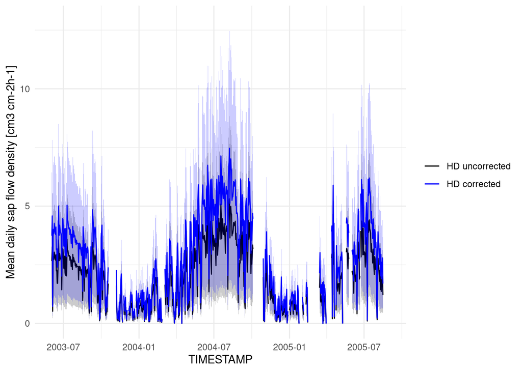

```r
ESP_VAL_SOR_sw<- read_sfn_data('ESP_VAL_SOR',folder=folder_sapwood)

esp_val_sor_unc<- sf_add_uncert(ESP_VAL_SOR_sw,nsd=2)

esp_val_sor_unc%>%
  group_by(tree,day=lubridate::floor_date(TIMESTAMP,'day')) %>%
  summarise(
  across(contains('sfd'),mean,na.rm=TRUE)
  ) %>%
  filter(tree%in%'ESP_VAL_SOR_Psy_Jt_12') %>%
  ggplot(aes(x=day,y=sfd))+
  geom_ribbon(aes(ymin=sfd_lo,ymax=sfd_up),fill='black', alpha=0.2)+
  geom_line(aes(x=day,y=sfd,col='black'))+
geom_line(aes(x=day,y=sfdcor,col='blue'))+
  geom_ribbon(aes(ymin=sfdcor_lo,ymax=sfdcor_up),fill='blue',alpha=0.2)+
    scale_colour_manual(name=NULL,values=c('black','blue'),
    labels=c('HD uncorrected','HD corrected'))+
  labs(x='TIMESTAMP',y='Mean daily sap flow density [cm3 cm-2h-1]')+
   theme_minimal()
```

# Compensation heat pulse

Same for CHP Pinus sylvestris from Devilla, Scotland

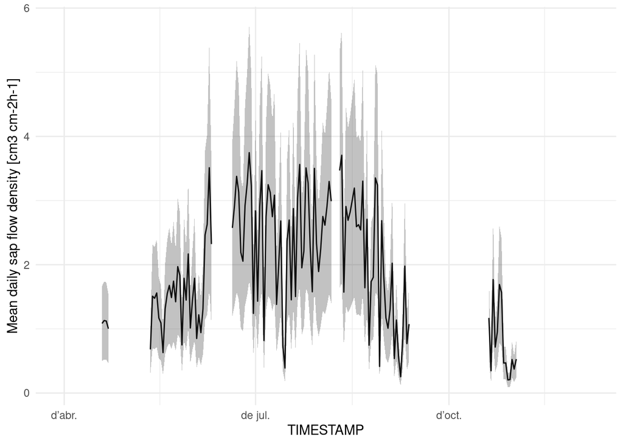

```r
 # sfn_sites_in_folder(folder='data/0.1.5/RData/sapwood') %>%
 #  filter_sites_by_md(pl_sens_meth=='CHP',
 #                     metadata=read_sfn_data(folder=folder_sapwood))

GBR_DEV_CON_sw<- read_sfn_data('GBR_DEV_CON',folder='data/0.1.5/RData/sapwood')

gbr_dev_con_unc<- sf_add_uncert(GBR_DEV_CON_sw)

gbr_dev_con_unc%>%
  group_by(tree,day=lubridate::floor_date(TIMESTAMP,'day')) %>%
  summarise(
  across(contains('sfd'),mean,na.rm=TRUE)
  ) %>%
  filter(tree%in%'GBR_DEV_CON_Psy_Jt_2') %>%
  ggplot(aes(x=day,y=sfd))+
geom_line(alpha=1)+
  geom_ribbon(aes(ymin=sfd_lo,ymax=sfd_up),alpha=0.3)+
    labs(x='TIMESTAMP',y='Mean daily sap flow density [cm3 cm-2h-1]')+
   theme_minimal()
```

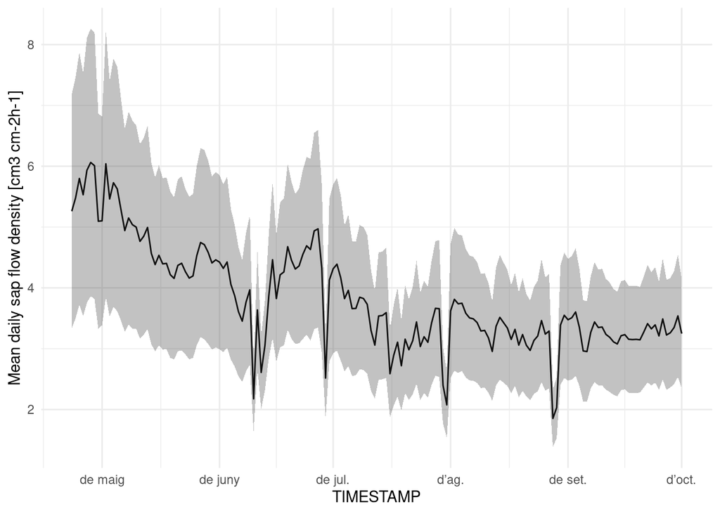

```r
AUS_KAR_sw<- read_sfn_data('AUS_KAR',folder='data/0.1.5/RData/sapwood')

aus_kar_unc<- sf_add_uncert(AUS_KAR_sw)

aus_kar_unc%>%
  group_by(tree,day=lubridate::floor_date(TIMESTAMP,'day')) %>%
  summarise(
  across(contains('sfd'),mean,na.rm=TRUE)
  ) %>%
  filter(tree%in%'AUS_KAR_Evi_Js_1') %>%
  ggplot(aes(x=day,y=sfd))+
geom_line(alpha=1)+
  geom_ribbon(aes(ymin=sfd_lo,ymax=sfd_up),alpha=0.3)+
    labs(x='TIMESTAMP',y='Mean daily sap flow density [cm3 cm-2h-1]')+
   theme_minimal()
```

## Uncertainty in sap flow from sapwood estimation

Here I estimate uncertainty in sap flow caused by uncertainty in sapwood estimation from allometry (P.sylvestris, Vallcebre). High and low uncertainty bounds are calculated from 95% prediction interval of sapwood area. I compare uncertainty from sapwood area estimation with methodological uncertainty.

```r
# Vallcebre P.sylvestris sapwood allometry

# Data
data_sw_ba <- tibble(
  sapwood_area_cm2=c(503.2, 168.3, 181.9, 147.4, 24.6, 313.6, 186.2, 32.9, 98.1,
  44.4, 81, 290.8, 321.8, 787.7, 554.5, 471, 961.5, 760.9),
basal_area_cm2=c(649.2, 203.6, 212.5, 160.6, 28.3, 371.5, 246.1, 44.2, 122.7,
  51.5, 105.7, 356.3, 404.7, 956.6, 613.6, 559.9, 1023.5, 989.8)
)
# Model
modsw <- lm(log(sapwood_area_cm2)~log(basal_area_cm2),data=data_sw_ba)

# Calculations
esp_val_sor_unc_sf <- esp_val_sor_unc %>%
  mutate(pl_basal_area=pi*(pl_dbh/2)^2,
  sw_area_mean=exp(predict(modsw,newdata=data.frame(basal_area_cm2=pl_basal_area),
                       interval='prediction')[,'fit']),
  sw_area_lo=exp(predict(modsw,newdata=data.frame(basal_area_cm2=pl_basal_area),
                       interval='prediction')[,'lwr']),
    sw_area_up=exp(predict(modsw,newdata=data.frame(basal_area_cm2=pl_basal_area),
                       interval='prediction')[,'upr']),
# Sw area uncertainty
sfd_mean = sfd*sw_area_mean,
sfd_uncsw_lo = sfd*sw_area_lo,
sfd_uncsw_up = sfd*sw_area_up,

# Method uncertainty
sfd_uncmeth_lo = sfd_lo*sw_area_mean,
sfd_uncmeth_up = sfd_up*sw_area_mean,

  )
```

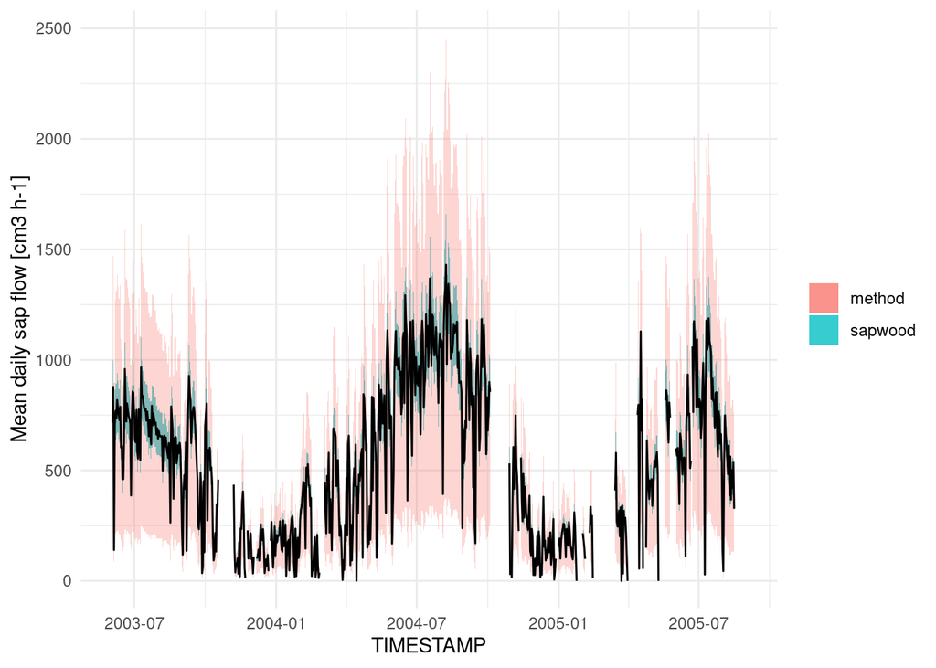

```r
esp_val_sor_unc_sf %>%
  group_by(tree,day=lubridate::floor_date(TIMESTAMP,'day')) %>%
  summarise(
  across(contains('sfd'),mean,na.rm=TRUE)
  ) %>%
  filter(tree=='ESP_VAL_SOR_Psy_Jt_12') %>%
  ggplot(aes(x=day,y=sfd_mean))+
  geom_ribbon(aes(ymin=sfd_uncsw_lo,ymax=sfd_uncsw_up,fill='sapwood'),alpha=0.7)+
  geom_ribbon(aes(ymin=sfd_uncmeth_lo,ymax=sfd_uncmeth_up,fill='method'),alpha=0.3)+
    geom_line(col='black')+
    labs(x='TIMESTAMP',y='Mean daily sap flow [cm3 h-1]')+
    theme_minimal()+
theme(legend.title = element_blank())
```